# day2_exercise

2024-07-23

###### Course 22123: Computational precision medicine

###### Day 2 practical: working with gene expression data in R

###### 02/06/2023

###### Technical University of Denmark

#### Load necessary packages (you can back fill once you know what packages you will use)

```r
library(tidyverse)
```

#### Load expression data from Xena (“gene expression RNAseq” - “HTSeq - Counts”)

```r
gbm_counts <- read.table("../00_raw_data/TCGA-GBM.htseq_counts.tsv", header = TRUE, row.names = 1)
```

#### Un-“log2” the data

```r
gbm_counts <- round((2^gbm_counts)-1, digits = 0)
```

#### Check out the distribution of the expression of a sample or two. What kind of distribution are you looking at?

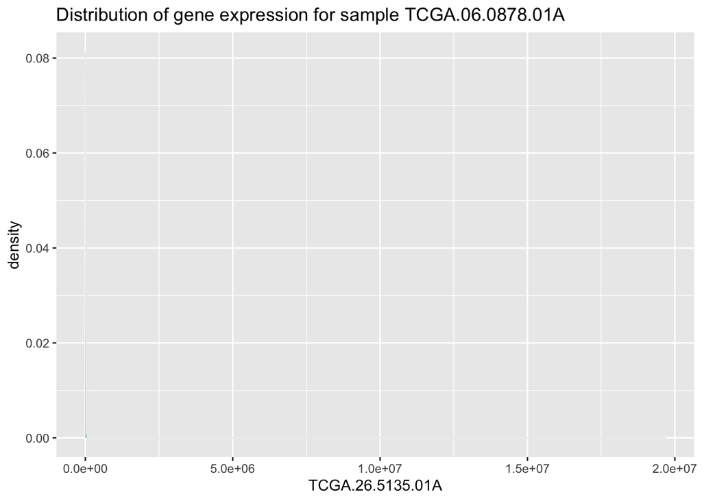

```r
ggplot(data = gbm_counts,
       mapping = aes(x = TCGA.26.5135.01A)) +
  geom_density(fill="#69b3a2", color="#e9ecef", alpha=0.8) +
  ggtitle("Distribution of gene expression for sample TCGA.06.0878.01A")
```

#### Load expression data from Xena (“gene expression RNAseq” - “HTSeq - FPKM”) - you should be working with this from now on

```r
gbm_fpkm <- read.table("../00_raw_data/TCGA-GBM.htseq_fpkm.tsv", header = TRUE, row.names = 1)
```

#### Check out the distribution of the expression of a sample or two. What changed? Why should we transform the raw counts?

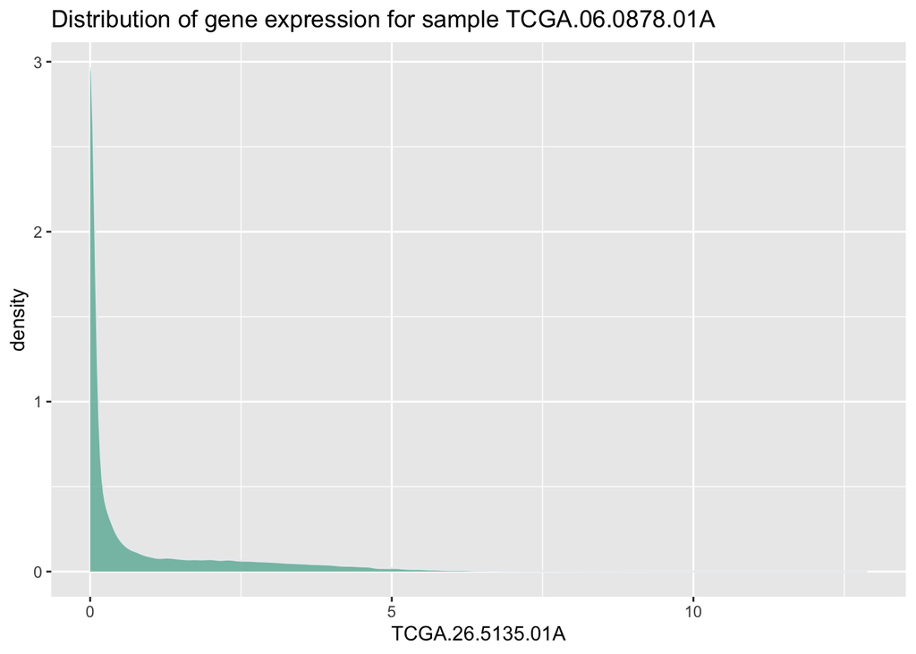

```r
ggplot(data = gbm_fpkm,
       mapping = aes(x = TCGA.26.5135.01A)) +
  geom_density(fill="#69b3a2", color="#e9ecef", alpha=0.8) +
  ggtitle("Distribution of gene expression for sample TCGA.06.0878.01A")
```

#### Load phenotype data from Xena (“phenotype” - “phenotype”)

```r
gbm_pheno <- read.table("../00_raw_data/TCGA-GBM.GDC_phenotype.tsv", header = TRUE, sep = "\t", quote="")
```

#### Take a closer look at the column called “sample_type.samples” and read here: https://gdc.cancer.gov/resources-tcga-users/tcga-code-tables/sample-type-codes

```r
table(gbm_pheno$sample_type.samples)
```

```
##
##       Primary Tumor     Recurrent Tumor Solid Tissue Normal
##                 618                  13                  40
```

#### Take a closer look at the column called “batch_number”

```r
table(gbm_pheno$batch_number)
```

```
##
##   1.96.0  10.84.0 111.64.0 130.66.0  16.87.0 174.58.0   2.96.0  20.81.0
##       25       29       39       40       50        2       17        1
##  20.86.0  26.75.0   3.92.0   3.96.0   3.97.0 346.45.0 378.35.0  38.74.0
##       48       48        1        1       22       11        1       29
##  4.100.0 402.37.0   5.90.0   6.94.0  62.68.0  62.73.0  62.74.0   7.94.0
##       48        6       66       57        1        1       25       27
##  79.66.0   8.90.0   8.94.0   8.95.0
##       35        2       10       29
```

#### Extract both those variables from the phenotype table along with the column called “submitter_id.samples”.

```r
gbm_pheno <- gbm_pheno %>%
              select(c("submitter_id.samples", "batch_number", "sample_type.samples"))
```

#### Do a little cleanup:

#### Rename sample type ids to match those in your expression table columns

```r
gbm_pheno <- gbm_pheno %>%
  mutate(across("submitter_id.samples", str_replace, '-', '.'))
```

#### Subset the phenotype table to contain only the samples you have expression data for

```r
gbm_pheno <- gbm_pheno %>%
  filter(submitter_id.samples %in% colnames(gbm_fpkm))
```

#### Optional: save Rdata object for later use

```r
save(gbm_counts, gbm_fpkm, gbm_pheno, file = "../01_tidy_data/gbm.Rdata")
```

#### Calculate PCA on count matrix

```r
pca_count <- prcomp(t(gbm_counts), scale. = TRUE)
```

#### Why did this not work?

It is because some of the genes have zero variance.

#### Solve the problem and try again

```r
gbm_counts <- gbm_counts %>%
                filter(rowSums(gbm_counts) > 0)

pca_count <- prcomp(t(gbm_counts), scale. = TRUE)
```

#### Check out how much variance is explained

```r
summary(pca_count)
```

```
## Importance of components:
##                           PC1      PC2      PC3      PC4      PC5      PC6
## Standard deviation     77.900 57.13691 46.05509 41.40269 38.92957 36.26198
## Proportion of Variance  0.108  0.05813  0.03777  0.03052  0.02699  0.02341
## Cumulative Proportion   0.108  0.16619  0.20395  0.23448  0.26146  0.28488
##                             PC7      PC8      PC9     PC10     PC11    PC12
## Standard deviation     32.41948 32.18639 29.08490 26.82237 26.56658 25.3025
## Proportion of Variance  0.01871  0.01845  0.01506  0.01281  0.01257  0.0114
## Cumulative Proportion   0.30359  0.32204  0.33710  0.34991  0.36248  0.3739
##                            PC13     PC14     PC15     PC16     PC17     PC18
## Standard deviation     24.81084 24.05844 23.96796 23.63127 23.31696 22.64158
## Proportion of Variance  0.01096  0.01031  0.01023  0.00994  0.00968  0.00913
## Cumulative Proportion   0.38484  0.39515  0.40538  0.41532  0.42500  0.43413
##                           PC19     PC20     PC21     PC22     PC23    PC24
## Standard deviation     22.4762 21.93341 21.35564 20.98106 20.89380 20.2508
## Proportion of Variance  0.0090  0.00857  0.00812  0.00784  0.00777  0.0073
## Cumulative Proportion   0.4431  0.45169  0.45981  0.46765  0.47542  0.4827
##                            PC25     PC26   PC27     PC28     PC29    PC30
## Standard deviation     20.13825 19.90290 19.823 19.62346 19.36299 19.1077
## Proportion of Variance  0.00722  0.00705  0.007  0.00686  0.00668  0.0065
## Cumulative Proportion   0.48995  0.49700  0.504  0.51085  0.51753  0.5240
##                            PC31     PC32     PC33     PC34    PC35     PC36
## Standard deviation     19.05482 18.68888 18.57194 18.48937 18.1992 18.01722
## Proportion of Variance  0.00647  0.00622  0.00614  0.00609  0.0059  0.00578
## Cumulative Proportion   0.53050  0.53671  0.54286  0.54894  0.5548  0.56062
##                            PC37    PC38     PC39     PC40     PC41     PC42
## Standard deviation     17.94371 17.8844 17.81450 17.54368 17.51481 17.43267
## Proportion of Variance  0.00573  0.0057  0.00565  0.00548  0.00546  0.00541
## Cumulative Proportion   0.56635  0.5720  0.57770  0.58318  0.58864  0.59406
##                            PC43     PC44    PC45     PC46     PC47     PC48
## Standard deviation     17.34520 17.31259 17.2451 16.97925 16.86641 16.82315
## Proportion of Variance  0.00536  0.00534  0.0053  0.00513  0.00507  0.00504
## Cumulative Proportion   0.59941  0.60475  0.6100  0.61518  0.62024  0.62528
##                            PC49     PC50    PC51     PC52    PC53     PC54
## Standard deviation     16.65060 16.60607 16.4218 16.29533 16.2531 16.15371
## Proportion of Variance  0.00494  0.00491  0.0048  0.00473  0.0047  0.00465
## Cumulative Proportion   0.63022  0.63513  0.6399  0.64466  0.6494  0.65401
##                            PC55     PC56     PC57     PC58     PC59     PC60
## Standard deviation     16.13631 15.98114 15.95025 15.91730 15.84368 15.73714
## Proportion of Variance  0.00464  0.00455  0.00453  0.00451  0.00447  0.00441
```

[output cut: 62 more lines]

```
## Standard deviation     10.77614 10.68440 10.57843 10.54433 10.48773 10.45163
## Proportion of Variance  0.00207  0.00203  0.00199  0.00198  0.00196  0.00195
## Cumulative Proportion   0.96600  0.96803  0.97002  0.97200  0.97396  0.97590
##                           PC157    PC158    PC159    PC160    PC161  PC162
## Standard deviation     10.37391 10.28262 10.24974 10.10409 10.08388 9.7770
## Proportion of Variance  0.00192  0.00188  0.00187  0.00182  0.00181 0.0017
## Cumulative Proportion   0.97782  0.97970  0.98157  0.98339  0.98520 0.9869
##                          PC163  PC164   PC165   PC166   PC167   PC168   PC169
## Standard deviation     9.62841 9.4823 9.13889 9.07405 8.56644 8.41810 8.17892
## Proportion of Variance 0.00165 0.0016 0.00149 0.00147 0.00131 0.00126 0.00119
## Cumulative Proportion  0.98856 0.9902 0.99164 0.99311 0.99442 0.99568 0.99687
##                          PC170   PC171   PC172    PC173
## Standard deviation     8.04135 8.01690 6.84438 1.48e-12
## Proportion of Variance 0.00115 0.00114 0.00083 0.00e+00
## Cumulative Proportion  0.99802 0.99917 1.00000 1.00e+00
```

#### Is this more or less than you would expect?

Less than expected. PC1 and PC2 only 0.108 and 0.05813 respectively.

#### Plot the first two principal components of the PCA

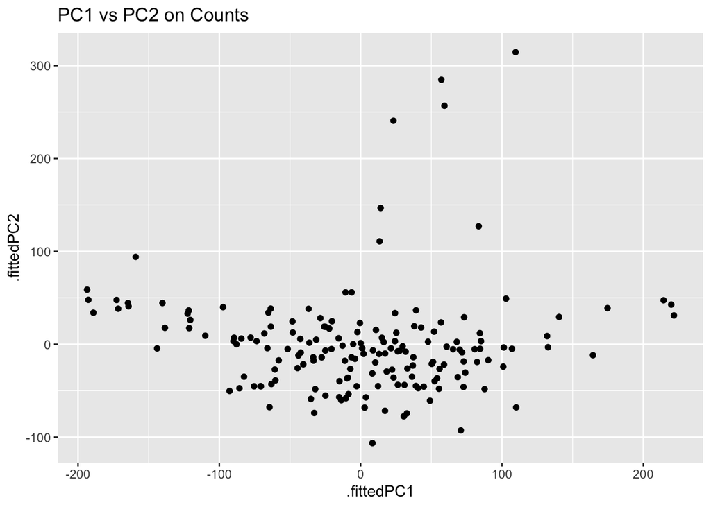

```r
library(broom)

pca_count %>%
  augment(t(gbm_counts)) %>%
  ggplot(aes(x = .fittedPC1, y = .fittedPC2)) +
  geom_point() +
  ggtitle("PC1 vs PC2 on Counts")
```

#### Now try the same with FPKM transformed data

```r
gbm_fpkm <- gbm_fpkm %>%
              filter(rowSums(gbm_fpkm) > 0)

pca_fpkm <- prcomp(t(gbm_fpkm), scale. = TRUE)

summary(pca_fpkm)
```

```
## Importance of components:
##                             PC1     PC2      PC3      PC4      PC5      PC6
## Standard deviation     66.13164 55.2313 47.80354 45.32316 42.80956 40.45885
## Proportion of Variance  0.07784  0.0543  0.04067  0.03656  0.03262  0.02914
## Cumulative Proportion   0.07784  0.1321  0.17281  0.20938  0.24200  0.27113
##                             PC7      PC8     PC9     PC10     PC11     PC12
## Standard deviation     35.34201 33.20786 31.5339 29.11340 28.27473 26.38666
## Proportion of Variance  0.02223  0.01963  0.0177  0.01509  0.01423  0.01239
## Cumulative Proportion   0.29337  0.31299  0.3307  0.34578  0.36001  0.37240
##                            PC13    PC14     PC15     PC16     PC17    PC18
## Standard deviation     25.70072 25.1910 23.85679 23.09396 22.57582 22.4825
## Proportion of Variance  0.01176  0.0113  0.01013  0.00949  0.00907  0.0090
## Cumulative Proportion   0.38416  0.3955  0.40559  0.41508  0.42415  0.4331
##                            PC19     PC20     PC21    PC22     PC23     PC24
## Standard deviation     21.79903 21.76234 21.23370 21.0641 20.78982 20.13235
## Proportion of Variance  0.00846  0.00843  0.00803  0.0079  0.00769  0.00721
## Cumulative Proportion   0.44161  0.45003  0.45806  0.4660  0.47365  0.48087
##                            PC25     PC26     PC27     PC28     PC29     PC30
## Standard deviation     20.06498 19.69632 19.64328 19.28029 19.15311 18.90260
## Proportion of Variance  0.00717  0.00691  0.00687  0.00662  0.00653  0.00636
## Cumulative Proportion   0.48803  0.49494  0.50180  0.50842  0.51495  0.52131
##                            PC31     PC32     PC33     PC34    PC35     PC36
## Standard deviation     18.84587 18.44534 18.34816 18.24846 18.2105 18.02535
## Proportion of Variance  0.00632  0.00606  0.00599  0.00593  0.0059  0.00578
## Cumulative Proportion   0.52763  0.53369  0.53968  0.54561  0.5515  0.55729
##                            PC37     PC38     PC39    PC40     PC41     PC42
## Standard deviation     17.75568 17.58976 17.45683 17.4218 17.33835 17.18976
## Proportion of Variance  0.00561  0.00551  0.00542  0.0054  0.00535  0.00526
## Cumulative Proportion   0.56290  0.56841  0.57384  0.5792  0.58459  0.58985
##                           PC43     PC44     PC45     PC46     PC47     PC48
## Standard deviation     17.0910 17.06351 16.99409 16.84126 16.68095 16.57007
## Proportion of Variance  0.0052  0.00518  0.00514  0.00505  0.00495  0.00489
## Cumulative Proportion   0.5950  0.60023  0.60537  0.61042  0.61537  0.62026
##                            PC49     PC50     PC51    PC52     PC53     PC54
## Standard deviation     16.47307 16.38643 16.32126 16.2482 16.17179 16.12770
## Proportion of Variance  0.00483  0.00478  0.00474  0.0047  0.00465  0.00463
## Cumulative Proportion   0.62509  0.62987  0.63461  0.6393  0.64396  0.64859
##                            PC55     PC56     PC57     PC58     PC59     PC60
## Standard deviation     16.05411 15.87989 15.83376 15.79022 15.76255 15.64537
## Proportion of Variance  0.00459  0.00449  0.00446  0.00444  0.00442  0.00436
```

[output cut: 62 more lines]

```
## Standard deviation     11.1222 11.09909 11.04618 11.01585 10.94406 10.88561
## Proportion of Variance  0.0022  0.00219  0.00217  0.00216  0.00213  0.00211
## Cumulative Proportion   0.9596  0.96175  0.96392  0.96608  0.96821  0.97032
##                           PC157    PC158    PC159    PC160    PC161    PC162
## Standard deviation     10.82549 10.78359 10.72221 10.65594 10.56280 10.44927
## Proportion of Variance  0.00209  0.00207  0.00205  0.00202  0.00199  0.00194
## Cumulative Proportion   0.97241  0.97448  0.97652  0.97855  0.98053  0.98247
##                           PC163   PC164    PC165    PC166    PC167   PC168
## Standard deviation     10.36539 10.3339 10.23096 10.19498 10.03662 9.96047
## Proportion of Variance  0.00191  0.0019  0.00186  0.00185  0.00179 0.00177
## Cumulative Proportion   0.98439  0.9863  0.98815  0.99000  0.99179 0.99356
##                          PC169  PC170   PC171   PC172    PC173
## Standard deviation     9.93288 9.7668 9.22930 9.08872 7.57e-13
## Proportion of Variance 0.00176 0.0017 0.00152 0.00147 0.00e+00
## Cumulative Proportion  0.99532 0.9970 0.99853 1.00000 1.00e+00
```

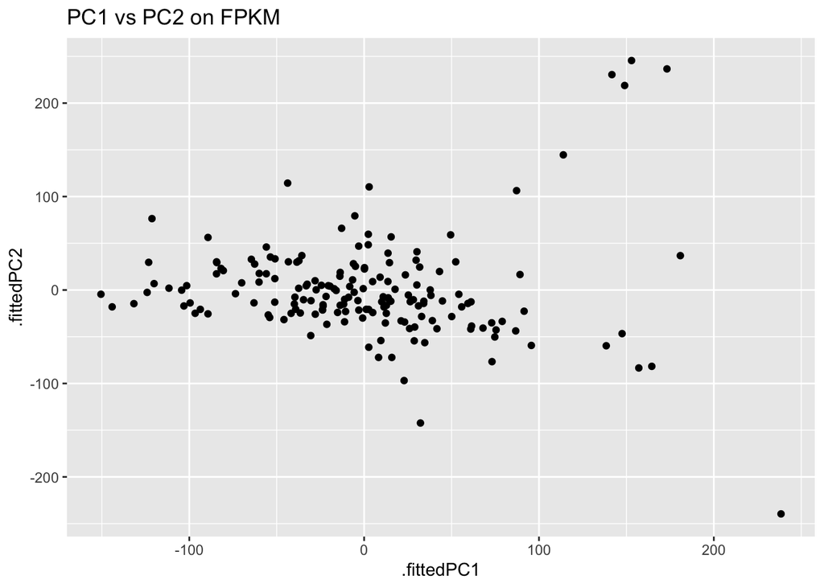

```r
pca_fpkm %>%
  augment(t(gbm_fpkm)) %>%
  ggplot(aes(x = .fittedPC1, y = .fittedPC2)) +
  geom_point() +
  ggtitle("PC1 vs PC2 on FPKM")
```

#### Do you get the same results in terms of variance explained and visualization of PC1 and PC2? Why/why not? Which do you think is better to use?

No.

#### Plot PCA of FPKM and color by batch

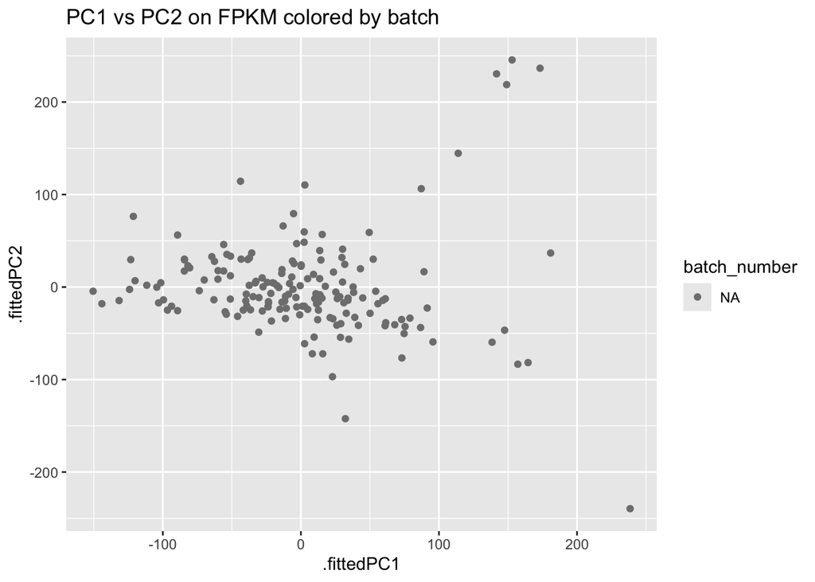

```r
pca_fpkm %>%
  augment(t(gbm_fpkm)) %>%
  left_join(gbm_pheno, by = c(".rownames" = "submitter_id.samples")) %>%
  ggplot(aes(x = .fittedPC1, y = .fittedPC2, colour = batch_number)) +
  geom_point() +
  ggtitle("PC1 vs PC2 on FPKM colored by batch")
```

#### Do you anticipate batch effects in this dataset?

No

#### Plot PCA and color by sample type

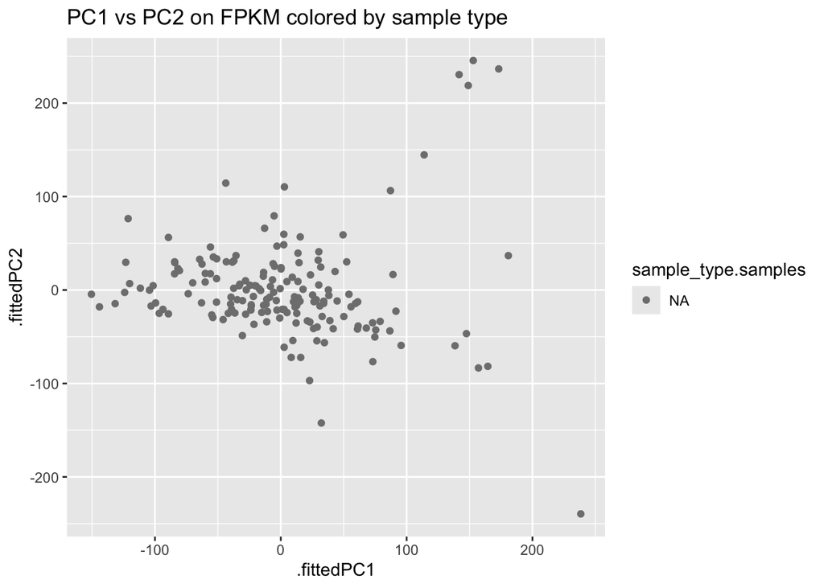

```r
pca_fpkm %>%
  augment(t(gbm_fpkm)) %>%
  left_join(gbm_pheno, by = c(".rownames" = "submitter_id.samples")) %>%
  ggplot(aes(x = .fittedPC1, y = .fittedPC2, colour = sample_type.samples)) +
  geom_point() +
  ggtitle("PC1 vs PC2 on FPKM colored by sample type")
```

#### Make a heatmap of the genes in the list “diff_genes.txt” (https://teaching.healthtech.dtu.dk/22123/diff_genes.txt)

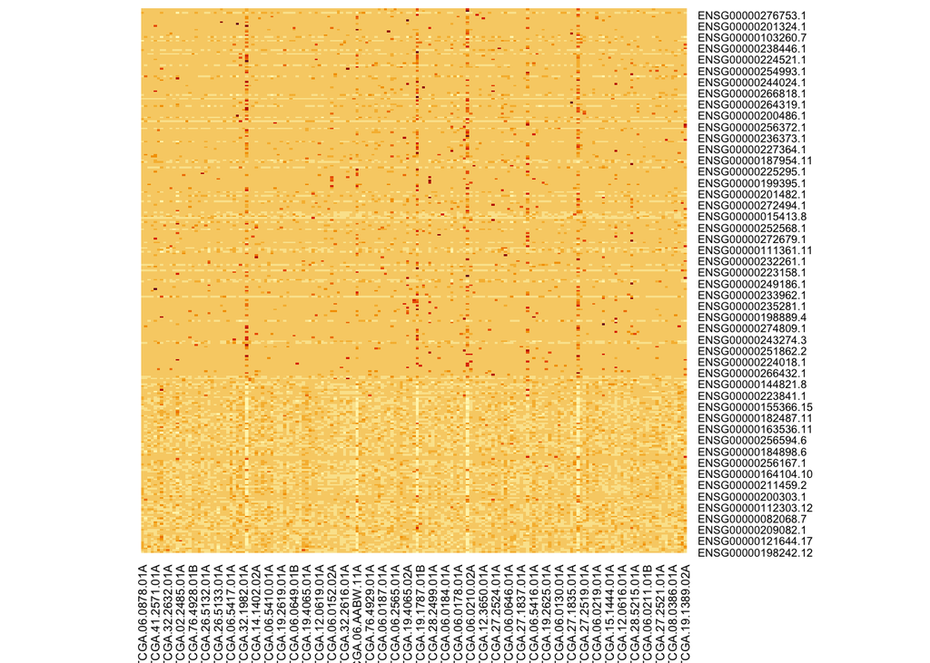

```r
diff_genes <-read.table(url("https://teaching.healthtech.dtu.dk/22123/diff_genes.txt"))

selected_fpkm <- gbm_fpkm %>%
                  filter(rownames(gbm_fpkm) %in% diff_genes$V1)

heatmap(as.matrix(selected_fpkm), scale = "row", Colv = NA, Rowv = NA)
```

#### Do the clusters in the dendrogram correspond to subtypes or batches?

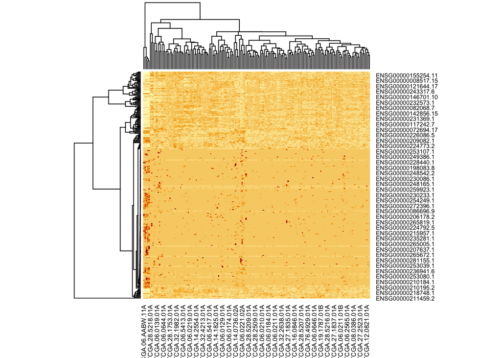

```r
heatmap(as.matrix(selected_fpkm), scale = "row")
```

#### Calculate the correlation between genes and visualize a low, medium, and high correlation pair in three separate scatter plots

#### Calculate the correlation between the genes “ENSG00000249568.1” and “ENSG00000249186.1”

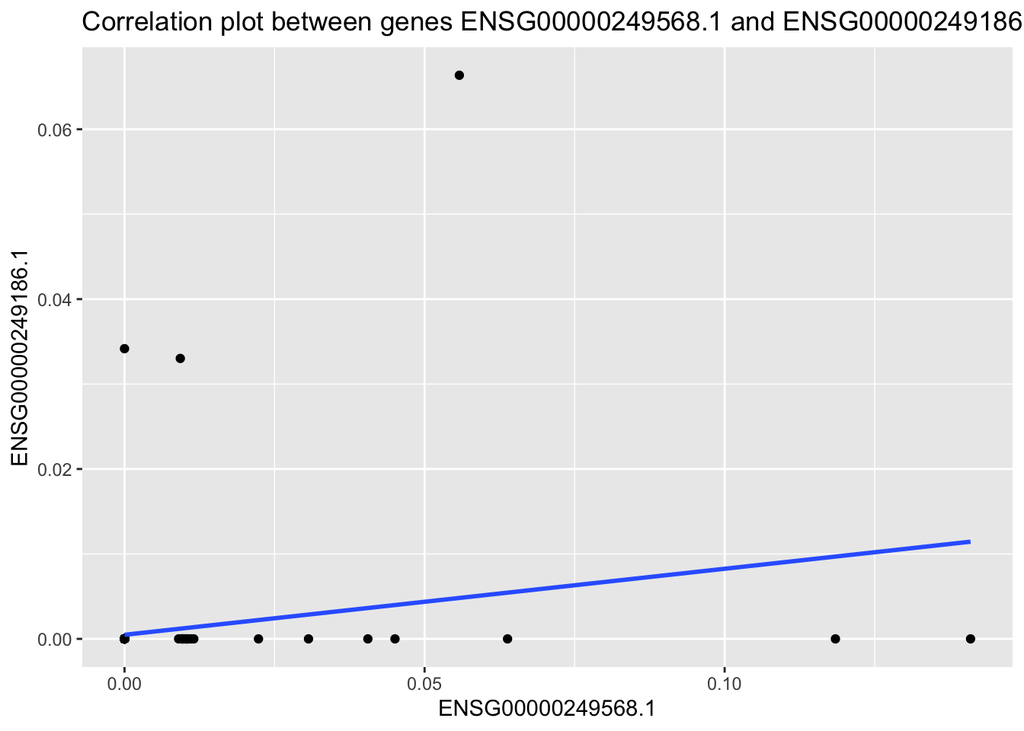

```r
t(gbm_fpkm) %>%
  ggplot(mapping = aes(x = ENSG00000249568.1, y = ENSG00000249186.1)) +
  geom_point() +
  geom_smooth(method = lm, se=FALSE) +
  ggtitle("Correlation plot between genes ENSG00000249568.1 and ENSG00000249186.1")
```

#### Visualize the expression of the gene “ENSG00000267112.1 in primary vs normal samples using boxplots

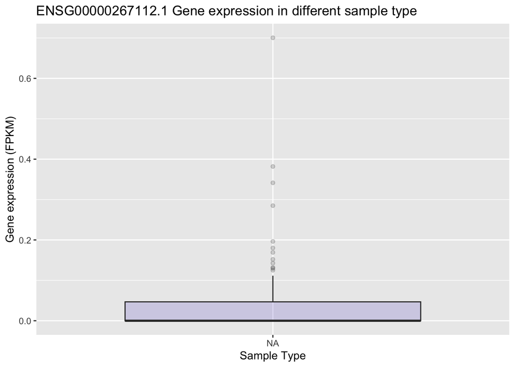

```r
gbm_fpkm %>%
  filter(rownames(gbm_fpkm) == "ENSG00000267112.1") %>%
  pivot_longer(cols = contains("TCGA"),
               names_to = "sample_id",
               values_to = "gene_expression") %>%
  left_join(gbm_pheno, by = c("sample_id" = "submitter_id.samples")) %>%
  ggplot(mapping = aes(x = as.factor(sample_type.samples), y = gene_expression)) +
  geom_boxplot(fill="slateblue", alpha=0.2) +
  xlab("Sample Type") +
  ylab("Gene expression (FPKM)") +
  ggtitle("ENSG00000267112.1 Gene expression in different sample type")
```